# RepData_PeerAssessment1

Amber Zhang

2018年10月12日

## Download and read in activitiy data

First we need to download the target data into the R work directory, then unzip and read in.

```r
download.file("https://d396qusza40orc.cloudfront.net/repdata%2Fdata%2Factivity.zip", destfile = "activity.zip", mode="wb")
unzip("activity.zip")
activityData <- read.csv(file = "activity.csv")
```

## Calculate the total number of steps taken per day

First we need to calculate the total number of steps taken per day.

```r
library(dplyr)
totalPerday <- activityData %>%
        select(steps, date) %>%
        group_by(date) %>%
        summarise(steps = sum(steps, na.rm = TRUE))
head(totalPerday)
```

```
## # A tibble: 6 x 2
##   date       steps
##   <fct>      <int>
## 1 2012-10-01     0
## 2 2012-10-02   126
## 3 2012-10-03 11352
## 4 2012-10-04 12116
## 5 2012-10-05 13294
## 6 2012-10-06 15420
```

## Make a histogram of the total number of steps taken each day

The plot is made based on ggplot2 system.

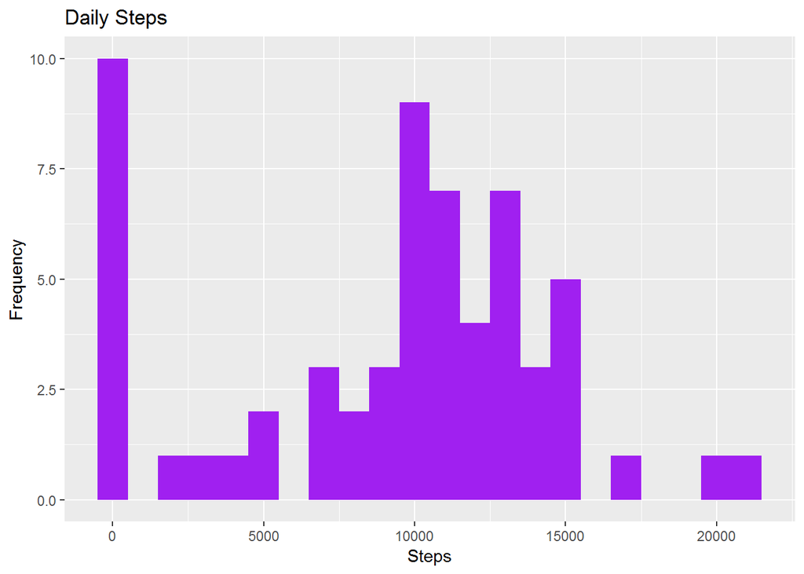

```r
library(ggplot2)
ggplot(totalPerday, aes(x = steps)) +
        geom_histogram(fill = "purple", binwidth = 1000) +
        labs(x = "Steps", y = "Frequency",
             title = "Daily Steps")
```

## Calculate the mean and median of the total number of steps taken per day

```r
mean_step <- mean(totalPerday$steps, na.rm = TRUE)
median_step <- median(totalPerday$steps, na.rm = TRUE)
mean_step
```

```
## [1] 9354.23
```

```r
median_step
```

```
## [1] 10395
```

## The average daily activity pattern

1. Make a time series plot of the 5-minute interval (x-axis) and the average number of steps taken, averaged across all days (y-axis)

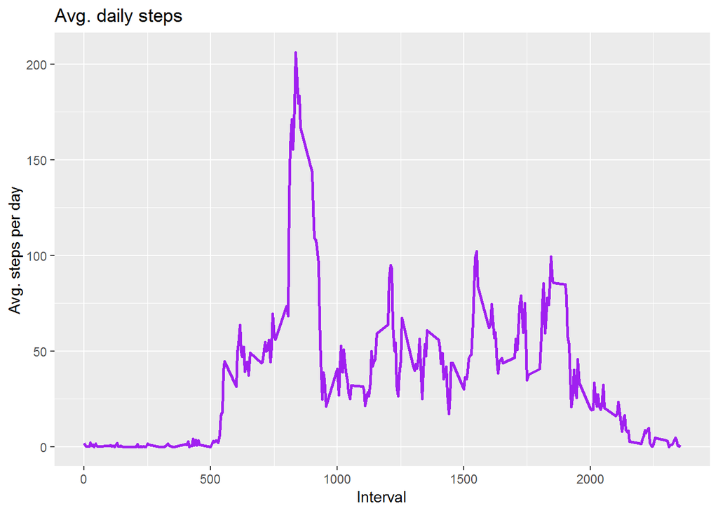

```r
avgpattern <- activityData %>%
        select(steps, interval) %>%
        group_by(interval) %>%
        summarise(avgsteps = mean(steps, na.rm = TRUE))
ggplot(avgpattern, aes(x = interval, y = avgsteps)) +
        geom_line(color = "purple", size = 1) +
        labs(x = "Interval", y = "Avg. steps per day",
             title = "Avg. daily steps")
```

## The maximum number of steps

2.Which 5-minute interval, on average across all the days in the dataset, contains the maximum number of steps?

```r
avgpattern %>%
        slice(which.max(avgsteps))
```

```
## # A tibble: 1 x 2
##   interval avgsteps
##      <int>    <dbl>
## 1      835     206.
```

## Imputing missing values

1.Calculate and report the total number of missing values in the dataset

```r
totalNA <- sum(is.na(activityData))
totalNA
```

```
## [1] 2304
```

## New dataset with missing data filled in

Create a new dataset that is equal to the original dataset but with the missing data filled in.

```r
filterNA <- activityData
filterNA[is.na(filterNA)] <- 0
```

## Make a new histogram

```r
totalPerday2 <- filterNA %>%
        select(steps, date) %>%
        group_by(date) %>%
        summarise(steps = sum(steps, na.rm = TRUE))
head(totalPerday2)
```

```
## # A tibble: 6 x 2
##   date       steps
##   <fct>      <dbl>
## 1 2012-10-01     0
## 2 2012-10-02   126
## 3 2012-10-03 11352
## 4 2012-10-04 12116
## 5 2012-10-05 13294
## 6 2012-10-06 15420
```

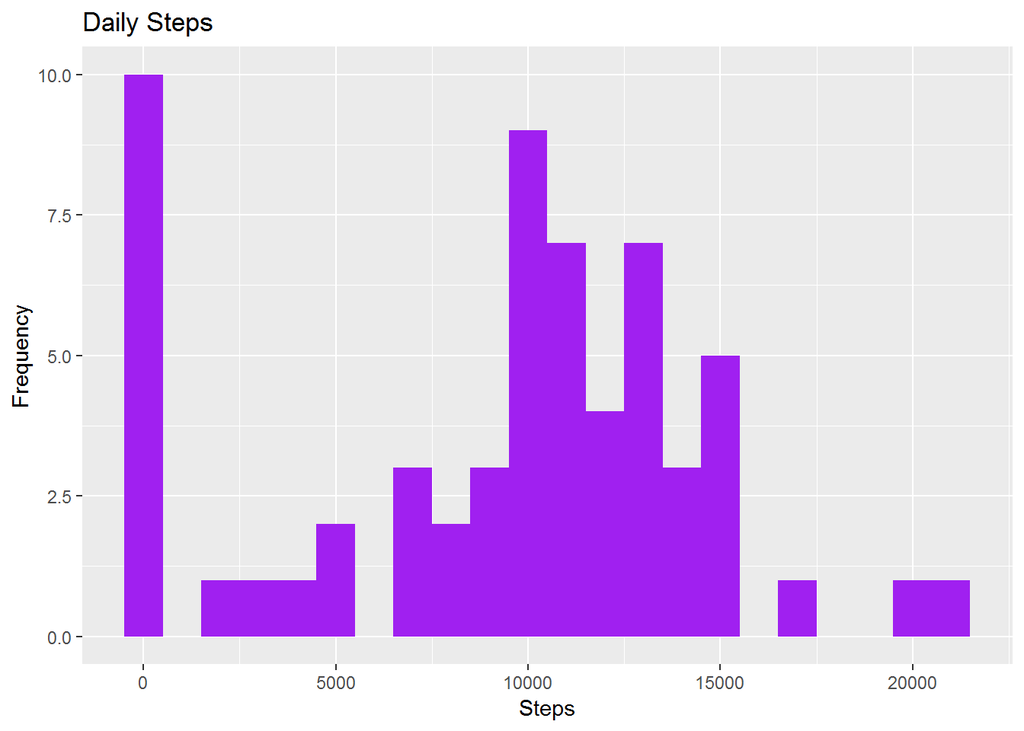

```r
ggplot(totalPerday2, aes(x = steps)) +
        geom_histogram(fill = "purple", binwidth = 1000) +
        labs(x = "Steps", y = "Frequency",
             title = "Daily Steps")
```

## Are there differences in activity patterns between weekdays and weekends?

```r
library(data.table)
activityData <- fread("activity.csv")
activityData[,date := as.POSIXct(date, format = "%Y-%m-%d")]
activityData[,  `Day of Week`:= weekdays(x = date)]
activityData[grepl(pattern = "星期一|星期二|星期三|星期四|星期五",
                   x = `Day of Week`), "weekday or weekend"] <- "weekday"
activityData[grepl(pattern = "星期六|星期日", x = `Day of Week`),
             "weekday or weekend"] <- "weekend"
activityData[,`weekday or weekend` := as.factor(`weekday or weekend`)]
head(activityData)
```

```
##    steps       date interval Day of Week weekday or weekend
## 1:    NA 2012-10-01        0      星期一            weekday
## 2:    NA 2012-10-01        5      星期一            weekday
## 3:    NA 2012-10-01       10      星期一            weekday
## 4:    NA 2012-10-01       15      星期一            weekday
## 5:    NA 2012-10-01       20      星期一            weekday
## 6:    NA 2012-10-01       25      星期一            weekday
```

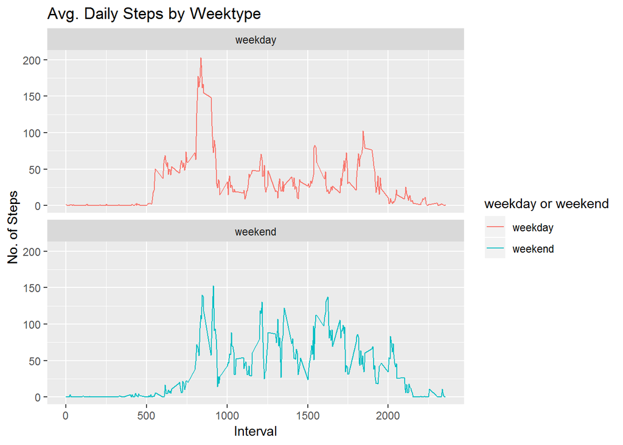

```r
activityData[is.na(steps), "steps"] <- activityData[, c(lapply(.SD, median, na.rm = TRUE)), .SDcols = c("steps")]
intervaldata <- activityData[, c(lapply(.SD, mean, na.rm = TRUE)), .SDcols = c("steps"), by = .(interval, `weekday or weekend`)]
ggplot(intervaldata, aes(x = interval, y = steps,
                         color = `weekday or weekend`)) +
        geom_line() +
        labs(title = "Avg. Daily Steps by Weektype", x = "Interval",
             y = "No. of Steps") +
        facet_wrap(~`weekday or weekend` , ncol = 1, nrow=2)
```